# BacLe Project4 Bank Churn Prediction Updated 082024

Bank Churn Prediction

## Problem Statement

### Context

Businesses like banks which provide service have to worry about problem of 'Customer Churn' i.e. customers leaving and joining another service provider. It is important to understand which aspects of the service influence a customer's decision in this regard. Management can concentrate efforts on improvement of service, keeping in mind these priorities.

### Objective

You as a Data scientist with the bank need to build a neural network based classifier that can determine whether a customer will leave the bank or not in the next 6 months.

### Data Dictionary

- CustomerId: Unique ID which is assigned to each customer
- Surname: Last name of the customer
- CreditScore: It defines the credit history of the customer.
- Geography: A customer’s location
- Gender: It defines the Gender of the customer
- Age: Age of the customer
- Tenure: Number of years for which the customer has been with the bank
- NumOfProducts: refers to the number of products that a customer has purchased through the bank.
- Balance: Account balance
- HasCrCard: It is a categorical variable which decides whether the customer has credit card or not.
- EstimatedSalary: Estimated salary
- isActiveMember: Is is a categorical variable which decides whether the customer is active member of the bank or not ( Active member in the sense, using bank products regularly, making transactions etc )
- Exited : whether or not the customer left the bank within six month. It can take two values

** 0=No ( Customer did not leave the bank ) ** 1=Yes ( Customer left the bank )

## Importing necessary libraries

```python
# Installing the libraries with the specified version.
!pip install scikeras tensorflow scikit-learn scikit-optimize shap seaborn==0.13.1 matplotlib==3.7.1 numpy==1.25.2 pandas==2.0.3 imbalanced-learn==0.12.3 -q --user
!pip install keras-tuner --upgrade
```

```python
# libaries for data manipulation & visualization
import pandas as pd
import numpy as np
import matplotlib.pyplot as plt
%matplotlib inline
import seaborn as sns
pd.set_option('display.max_columns', None)
pd.set_option('display.max_colwidth', 100)
pd.set_option('display.float_format', lambda x: '%.3f' % x) # To suppress scientific notations

# libaries for model building & processing
from sklearn import metrics
from sklearn.metrics import (
    f1_score,
    accuracy_score,
    recall_score,
    precision_score,
    confusion_matrix,
    roc_auc_score,
    RocCurveDisplay,
    roc_curve,
    classification_report,
)
from sklearn.model_selection import (
    train_test_split,
    StratifiedKFold, KFold,
    cross_val_score, cross_validate,
    RandomizedSearchCV, GridSearchCV,
)
from sklearn.preprocessing import StandardScaler, OneHotEncoder
from sklearn.compose import ColumnTransformer
from sklearn.pipeline import Pipeline
from sklearn import set_config
set_config(transform_output='pandas', display='diagram')

from skopt import BayesSearchCV

from imblearn.over_sampling import SMOTE
from imblearn.pipeline import Pipeline as imbPipeline

import tensorflow
import tensorflow as tf
from tensorflow import keras
from tensorflow.keras.models import Sequential
from tensorflow.keras.layers import Dense
from tensorflow.keras.layers import Dense, Input, Dropout,BatchNormalization
from tensorflow.keras import backend
from tensorflow.keras.callbacks import EarlyStopping

import keras_tuner as kt
import keras

from scikeras.wrappers import KerasClassifier

import random
import time
import shap
import joblib

# To supress warnings
import warnings
warnings.filterwarnings('ignore')
```

## Loading the dataset

```python
bankData = pd.read_csv('Churn.csv')
df = bankData.copy()
```

## Data Overview

```python
pd.concat([df.head(), df.tail()])
```

|  | RowNumber | CustomerId | Surname | CreditScore | Geography | Gender | Age | Tenure | Balance | NumOfProducts | HasCrCard | IsActiveMember | EstimatedSalary | Exited |
| --- | --- | --- | --- | --- | --- | --- | --- | --- | --- | --- | --- | --- | --- | --- |
| 0 | 1 | 15634602 | Hargrave | 619 | France | Female | 42 | 2 | 0.000 | 1 | 1 | 1 | 101348.880 | 1 |
| 1 | 2 | 15647311 | Hill | 608 | Spain | Female | 41 | 1 | 83807.860 | 1 | 0 | 1 | 112542.580 | 0 |
| 2 | 3 | 15619304 | Onio | 502 | France | Female | 42 | 8 | 159660.800 | 3 | 1 | 0 | 113931.570 | 1 |
| 3 | 4 | 15701354 | Boni | 699 | France | Female | 39 | 1 | 0.000 | 2 | 0 | 0 | 93826.630 | 0 |
| 4 | 5 | 15737888 | Mitchell | 850 | Spain | Female | 43 | 2 | 125510.820 | 1 | 1 | 1 | 79084.100 | 0 |
| 9995 | 9996 | 15606229 | Obijiaku | 771 | France | Male | 39 | 5 | 0.000 | 2 | 1 | 0 | 96270.640 | 0 |
| 9996 | 9997 | 15569892 | Johnstone | 516 | France | Male | 35 | 10 | 57369.610 | 1 | 1 | 1 | 101699.770 | 0 |
| 9997 | 9998 | 15584532 | Liu | 709 | France | Female | 36 | 7 | 0.000 | 1 | 0 | 1 | 42085.580 | 1 |
| 9998 | 9999 | 15682355 | Sabbatini | 772 | Germany | Male | 42 | 3 | 75075.310 | 2 | 1 | 0 | 92888.520 | 1 |
| 9999 | 10000 | 15628319 | Walker | 792 | France | Female | 28 | 4 | 130142.790 | 1 | 1 | 0 | 38190.780 | 0 |

```python
df.shape
```

```
(10000, 14)
```

- There are 10000 rows, and 14 columns.

```python
df.info()
```

```
<class 'pandas.core.frame.DataFrame'>
RangeIndex: 10000 entries, 0 to 9999
Data columns (total 14 columns):
 #   Column           Non-Null Count  Dtype
---  ------           --------------  -----
 0   RowNumber        10000 non-null  int64
 1   CustomerId       10000 non-null  int64
 2   Surname          10000 non-null  object
 3   CreditScore      10000 non-null  int64
 4   Geography        10000 non-null  object
 5   Gender           10000 non-null  object
 6   Age              10000 non-null  int64
 7   Tenure           10000 non-null  int64
 8   Balance          10000 non-null  float64
 9   NumOfProducts    10000 non-null  int64
 10  HasCrCard        10000 non-null  int64
 11  IsActiveMember   10000 non-null  int64
 12  EstimatedSalary  10000 non-null  float64
 13  Exited           10000 non-null  int64
dtypes: float64(2), int64(9), object(3)
memory usage: 1.1+ MB
```

```python
df.isnull().sum()
```

```
RowNumber          0
CustomerId         0
Surname            0
CreditScore        0
Geography          0
Gender             0
Age                0
Tenure             0
Balance            0
NumOfProducts      0
HasCrCard          0
IsActiveMember     0
EstimatedSalary    0
Exited             0
dtype: int64
```

```python
df.duplicated().sum()
```

```
0
```

- There are 3 categorical features, and 11 numerical features
- There is no missing data, and no duplicates.

```python
df.describe(include=['number']).T
```

|  | count | mean | std | min | 25% | 50% | 75% | max |
| --- | --- | --- | --- | --- | --- | --- | --- | --- |
| RowNumber | 10000.000 | 5000.500 | 2886.896 | 1.000 | 2500.750 | 5000.500 | 7500.250 | 10000.000 |
| CustomerId | 10000.000 | 15690940.569 | 71936.186 | 15565701.000 | 15628528.250 | 15690738.000 | 15753233.750 | 15815690.000 |
| CreditScore | 10000.000 | 650.529 | 96.653 | 350.000 | 584.000 | 652.000 | 718.000 | 850.000 |
| Age | 10000.000 | 38.922 | 10.488 | 18.000 | 32.000 | 37.000 | 44.000 | 92.000 |
| Tenure | 10000.000 | 5.013 | 2.892 | 0.000 | 3.000 | 5.000 | 7.000 | 10.000 |
| Balance | 10000.000 | 76485.889 | 62397.405 | 0.000 | 0.000 | 97198.540 | 127644.240 | 250898.090 |
| NumOfProducts | 10000.000 | 1.530 | 0.582 | 1.000 | 1.000 | 1.000 | 2.000 | 4.000 |
| HasCrCard | 10000.000 | 0.706 | 0.456 | 0.000 | 0.000 | 1.000 | 1.000 | 1.000 |
| IsActiveMember | 10000.000 | 0.515 | 0.500 | 0.000 | 0.000 | 1.000 | 1.000 | 1.000 |
| EstimatedSalary | 10000.000 | 100090.240 | 57510.493 | 11.580 | 51002.110 | 100193.915 | 149388.247 | 199992.480 |
| Exited | 10000.000 | 0.204 | 0.403 | 0.000 | 0.000 | 0.000 | 0.000 | 1.000 |

```python
# Display the unique values in each numerical feature
print(df.select_dtypes(include=['number']).apply(lambda col: col.unique()))
```

```
RowNumber          [1, 2, 3, 4, 5, 6, 7, 8, 9, 10, 11, 12, 13, 14, 15, 16, 17, 18, 19, 20, 21, 22, 23, 24, 25, 26, ...
CustomerId         [15634602, 15647311, 15619304, 15701354, 15737888, 15574012, 15592531, 15656148, 15792365, 15592...
CreditScore        [619, 608, 502, 699, 850, 645, 822, 376, 501, 684, 528, 497, 476, 549, 635, 616, 653, 587, 726, ...
Age                [42, 41, 39, 43, 44, 50, 29, 27, 31, 24, 34, 25, 35, 45, 58, 32, 38, 46, 36, 33, 40, 51, 61, 49,...
Tenure                                                                              [2, 1, 8, 7, 4, 6, 3, 10, 5, 9, 0]
Balance            [0.0, 83807.86, 159660.8, 125510.82, 113755.78, 115046.74, 142051.07, 134603.88, 102016.72, 1431...
NumOfProducts                                                                                             [1, 3, 2, 4]
HasCrCard                                                                                                       [1, 0]
IsActiveMember                                                                                                  [1, 0]
EstimatedSalary    [101348.88, 112542.58, 113931.57, 93826.63, 79084.1, 149756.71, 10062.8, 119346.88, 74940.5, 717...
Exited                                                                                                          [1, 0]
dtype: object
```

```python
df.describe(include=['object']).T
```

|  | count | unique | top | freq |
| --- | --- | --- | --- | --- |
| Surname | 10000 | 2932 | Smith | 32 |
| Geography | 10000 | 3 | France | 5014 |
| Gender | 10000 | 2 | Male | 5457 |

```python
# Display the unique values in each category feature
print(df.select_dtypes(include=['object']).apply(lambda col: col.unique()))
```

```
Surname      [Hargrave, Hill, Onio, Boni, Mitchell, Chu, Bartlett, Obinna, He, H?, Bearce, Andrews, Kay, Chin...
Geography                                                                               [France, Spain, Germany]
Gender                                                                                            [Female, Male]
dtype: object
```

- The average Age is 39. The average Credit Score is 650.
- The average number of years a customer has been with the Bank is 5.
- The average Account Balance is \$76,486.

```python
# Dropping columns
df.drop(['RowNumber', 'CustomerId', 'Surname'], axis=1, inplace=True)
```

```python
# Identity numerical and categorical columns for EDA
num_cols = df.select_dtypes(include=np.number).columns.tolist()
cat_cols = df.select_dtypes(include=['object', 'category']).columns.tolist()
# Convert object datatypes to category.
df[cat_cols] = df[cat_cols].astype('category')
```

```python
df.dtypes
```

```
CreditScore           int64
Geography          category
Gender             category
Age                   int64
Tenure                int64
Balance             float64
NumOfProducts         int64
HasCrCard             int64
IsActiveMember        int64
EstimatedSalary     float64
Exited                int64
dtype: object
```

- The 3 unnecessary columns (RowNumber, CustomerId, and Surname) are dropped.
- The new number of columns is 11, including 2 categorical columns Geography, and Gender.

## Exploratory Data Analysis

```python
# function to plot a boxplot and a histogram along the same scale.
def histogram_boxplot(data, feature, figsize=(9, 5), kde=False, bins=None):
    '''
    Boxplot and histogram combined

    data: dataframe
    feature: dataframe column
    figsize: size of figure (default (12,7))
    kde: whether to the show density curve (default False)
    bins: number of bins for histogram (default None)
    '''
    f2, (ax_box2, ax_hist2) = plt.subplots(
        nrows=2,  # Number of rows of the subplot grid= 2
        sharex=True,  # x-axis will be shared among all subplots
        gridspec_kw={'height_ratios': (0.25, 0.75)},
        figsize=figsize,
    )  # creating the 2 subplots
    sns.boxplot(
        data=data, x=feature, ax=ax_box2,  showmeans = True, meanline=True,  color='violet'
    )  # boxplot will be created and a dashed line will indicate the mean value of the column
    sns.histplot(
        data=data, x=feature, kde=kde, ax=ax_hist2, bins=bins, palette='winter'
    ) if bins else sns.histplot(
        data=data, x=feature, kde=kde, ax=ax_hist2
    )  # For histogram
    ax_hist2.axvline(
        data[feature].mean(), color='green', linestyle='--'
    )  # Add mean to the histogram
    ax_hist2.axvline(
        data[feature].median(), color='black', linestyle='-'
    )  # Add median to the histogram
```

```python
# function to create labeled barplots
def labeled_barplot(data, feature, perc=False, n=None):
    '''
    Barplot with percentage at the top

    data: dataframe
    feature: dataframe column
    perc: whether to display percentages instead of count (default is False)
    n: displays the top n category levels (default is None, i.e., display all levels)
    '''

    total = len(data[feature])  # length of the column
    count = data[feature].nunique()
    if n is None:
        plt.figure(figsize=(count + 1, 5))
    else:
        plt.figure(figsize=(n + 1, 5))

    plt.xticks(rotation=90, fontsize=15)
    ax = sns.countplot(
        data=data,
        x=feature,
        palette='Paired',
        order=data[feature].value_counts().index[:n].sort_values(),
    )

    for p in ax.patches:
        if perc == True:
            label = '{:.1f}%'.format(
                100 * p.get_height() / total
            )  # percentage of each class of the category
        else:
            label = p.get_height()  # count of each level of the category

        x = p.get_x() + p.get_width() / 2  # width of the plot
        y = p.get_height()  # height of the plot

        ax.annotate(
            label,
            (x, y),
            ha='center',
            va='center',
            size=12,
            xytext=(0, 5),
            textcoords='offset points',
        )  # annotate the percentage

    plt.show()  # show the plot
```

```python
# Function to plot Stacked Barplot
def stacked_barplot(data, predictor, target):
    '''
    Print the category counts and plot a stacked bar chart

    data: dataframe
    predictor: independent variable
    target: target variable
    '''
    count = data[predictor].nunique()
    sorter = data[target].value_counts().index[-1]
    tab1 = pd.crosstab(data[predictor], data[target], margins=True, rownames=None).sort_values(
        by=sorter, ascending=False
    )
    tab1['% of 0'] = round(tab1[0]/tab1['All']*100, 2)
    tab1['% of 1'] = round(tab1[1]/tab1['All']*100, 2)
    print(tab1)
    print('-' * 120)
    tab = pd.crosstab(data[predictor], data[target], normalize='index').sort_values(
        by=sorter, ascending=False
    )
    tab.plot(kind='bar', stacked=True, figsize=(count + 1, 3))
    plt.legend(
        loc='lower left', frameon=False,
    )
    plt.legend(title=target, loc='upper left', bbox_to_anchor=(1, 1), labels=['0: Current', '1: Exited'])
    plt.show()
```

```python
### Function to plot distributions
def distribution_plot_wrt_target(data, predictor, target):

    fig, axs = plt.subplots(2, 2, figsize=(9, 6))

    target_uniq = data[target].unique()

    axs[0, 0].set_title('Distribution of target for target=' + str(target_uniq[0]))
    sns.histplot(
        data=data[data[target] == target_uniq[0]],
        x=predictor,
        kde=True,
        ax=axs[0, 0],
        color='teal',
    )

    axs[0, 1].set_title('Distribution of target for target=' + str(target_uniq[1]))
    sns.histplot(
        data=data[data[target] == target_uniq[1]],
        x=predictor,
        kde=True,
        ax=axs[0, 1],
        color='orange',
    )

    axs[1, 0].set_title('Boxplot w.r.t target')
    sns.boxplot(data=data, x=target, y=predictor, ax=axs[1, 0], palette='gist_rainbow')

    axs[1, 1].set_title('Boxplot (without outliers) w.r.t target')
    sns.boxplot(
        data=data,
        x=target,
        y=predictor,
        ax=axs[1, 1],
        showfliers=False,
        palette='gist_rainbow',
    )

    plt.tight_layout()
    plt.show()
```

### Univariate Analysis

```python
def hist_boxplots(data, cols, bins=8):
    plt.figure(figsize=(10,18))
    j = 1
    colors = sns.color_palette(n_colors=len(cols))

    for i, feature in enumerate(cols):
        plt.subplot(len(cols), 2, i+j)
        sns.boxplot(data=data, x=feature, showmeans = True, meanline=True, color=colors[i])
        plt.locator_params(axis='x', nbins=bins)
        plt.subplot(len(cols), 2, i+j+1)\

        ax = sns.histplot(data=data, x=feature, kde=True, color=colors[i])
        ax.axvline(data[feature].mean(), color='green', linestyle='--')
        ax.axvline(data[feature].median(), color='gray', linestyle='-')

        plt.locator_params(axis='x', nbins=bins)
        plt.subplots_adjust(wspace=0.3, hspace=0.3)
        j+=1
```

```python
# Function to plot countplot with percentage.
def multi_countplot(data, cols):
    plt.figure(figsize=(12,8))
    for i, feature in enumerate(cols):
        plt.subplot(2, 3, i+1)
        total_rows = data[feature].count()
        count = df[feature].nunique()
        ax = sns.countplot(data=data, x=feature, palette = 'colorblind', legend=True)
        for j in range (0, count):
            plt.bar_label(ax.containers[j],  fmt=lambda x: f'{(x/total_rows)*100:0.1f}%');
        plt.subplots_adjust(wspace=0.3, hspace=0.3);
```

```python
def multi_boxplots(cols:list, feature: str):
    plt.figure(figsize=(15,10))
    for i, var in enumerate(cols):
        plt.subplot(3, 3, i+1)
        sns.boxplot(x=df[feature], y=df[var], hue=df[feature], legend=False)
        plt.tight_layout()
        plt.title(var);
        plt.subplots_adjust(wspace=0.5, hspace=0.5);
```

```python
def outlier_summary(data, feature, target, flag):
    q1=data[data[target]==flag][feature].quantile(0.25)
    q3=data[data[target]==flag][feature].quantile(0.75)
    IQR=q3-q1
    min = (q1-1.5*IQR)
    if min < 0: min = 0
    max = (q3+1.5*IQR)
    summary = pd.DataFrame(
         {'Q1': q1, 'Q3': q3,
          'Min': min, 'Max': max,
          'Lower Qty': data[data[target]==flag][data[feature]<min][feature].value_counts().sum(),
          'Upper Qty': data[data[target]==flag][data[feature]>max][feature].value_counts().sum()
         }, index=[0])

    return summary
```

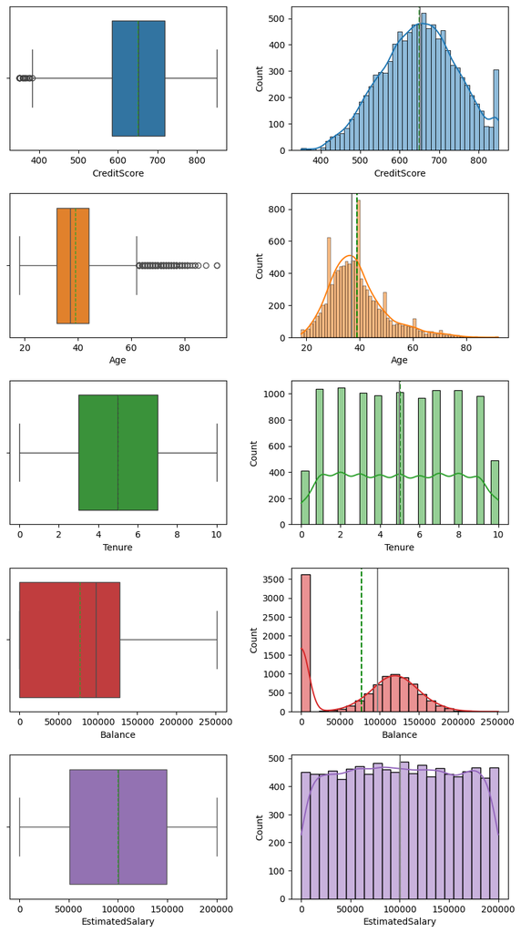

```python
hist_boxplots(df, ['CreditScore','Age','Tenure','Balance','EstimatedSalary'])
```

##### Observations:

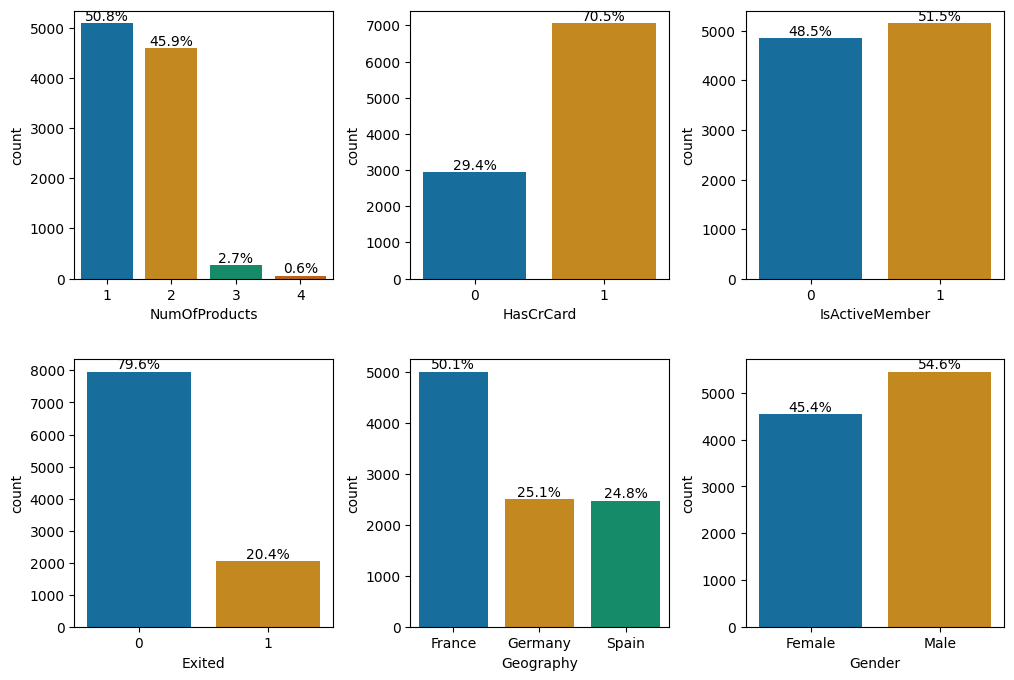

```python
multi_countplot(df, ['NumOfProducts','HasCrCard','IsActiveMember','Exited','Geography','Gender'])
```

##### Observations:

- Most customers about 97% have 1 or 2 Number of Products.
- About 70% of customers have a credit card.
- Only half of the customers are active members who make regular transactions.
- The target variable 'Exited' has an 80% / 20% split. It is imbalance data.
- Half of the customers are in France.
- About 55% of customers are Male.

### Bivariate Analysis

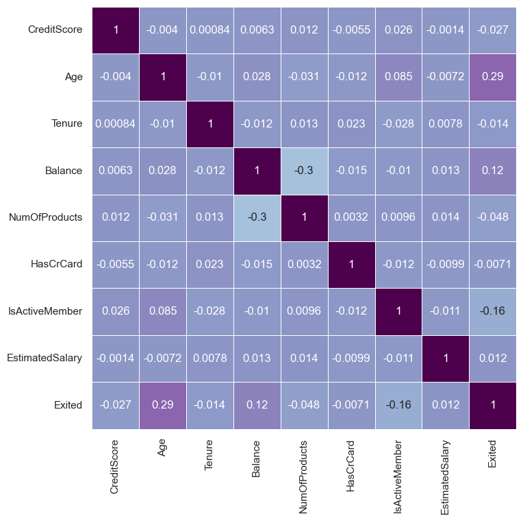

```python
sns.set(rc={'figure.figsize':(8,8)})
sns.heatmap(df.corr(numeric_only=True),annot=True,linewidths=.5,center=0,cbar=False,cmap='BuPu');
```

##### Observations:

- Age and Exited have a weak positive correlation at 0.29
- Balance and NumOfProducts have a weak negative correlation at -0.30.
- The rest of the features do not correlate with each other, no multicollinearity.

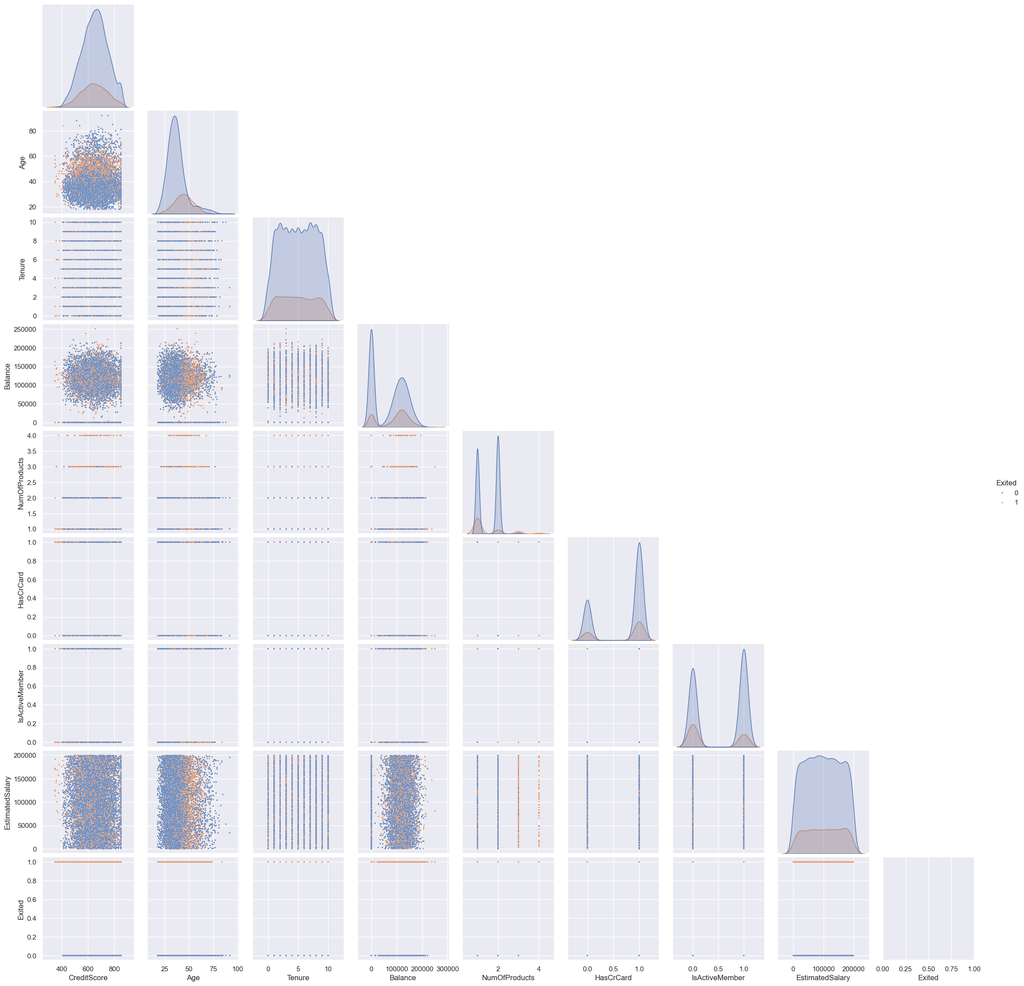

```python
sns.pairplot(df, vars=num_cols, hue='Exited', diag_kind='kde', corner=True, plot_kws={'s':5});
```

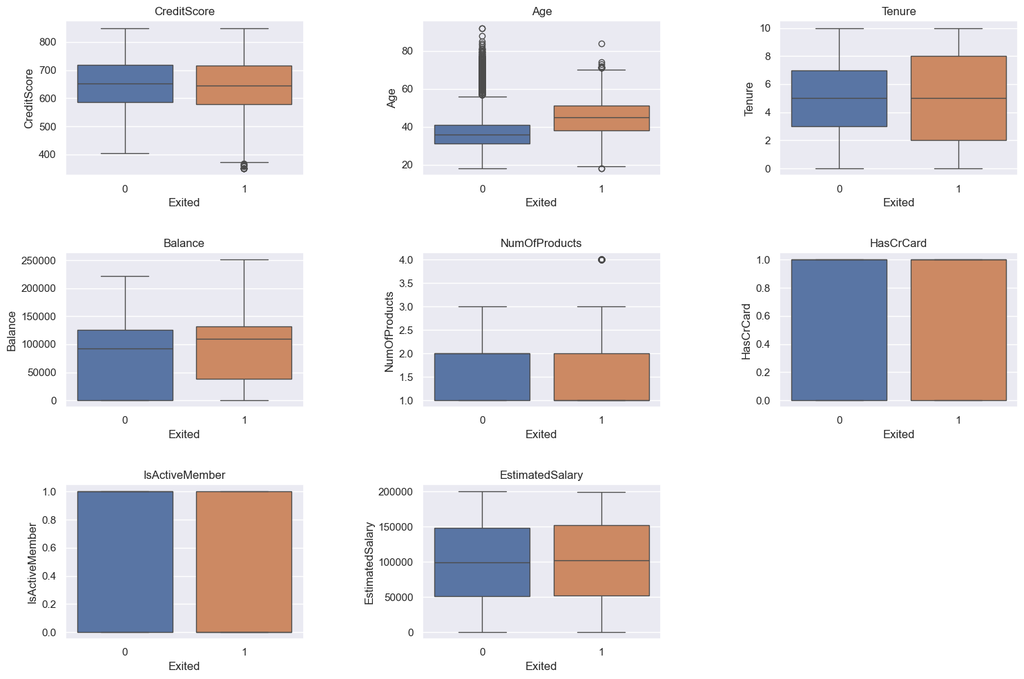

```python
multi_boxplots(list(filter(lambda x: x != 'Exited', num_cols)), 'Exited' )
```

```python
outlier_summary(df, 'Age', 'Exited', 1)
```

|  | Q1 | Q3 | Min | Max | Lower Qty | Upper Qty |
| --- | --- | --- | --- | --- | --- | --- |
| 0 | 38.000 | 51.000 | 18.500 | 70.500 | 2 | 11 |

```python
outlier_summary(df, 'Balance', 'Exited', 1)
```

|  | Q1 | Q3 | Min | Max | Lower Qty | Upper Qty |
| --- | --- | --- | --- | --- | --- | --- |
| 0 | 38340.020 | 131433.330 | 0 | 271073.295 | 0 | 0 |

```python
outlier_summary(df, 'Tenure', 'Exited', 0)
```

|  | Q1 | Q3 | Min | Max | Lower Qty | Upper Qty |
| --- | --- | --- | --- | --- | --- | --- |
| 0 | 3.000 | 7.000 | 0 | 13.000 | 0 | 0 |

##### Observations:

- The following features do not directly link to churn because the boxplots are nearly identical for both groups:
- - CreditScore, NumOfProducts, HasCrCard, isActiveMember, and EstimatedSalary.
- The Age of Churners is above 38.
- The Balance of Churners is above 38k.
- The Tenure of Churners is below 3 yrs and over 7 yrs.

```
Exited        0     1    All  % of 0  % of 1
Geography
All        7963  2037  10000  79.630  20.370
Germany    1695   814   2509  67.560  32.440
France     4204   810   5014  83.850  16.150
Spain      2064   413   2477  83.330  16.670
------------------------------------------------------------------------------------------------------------------------
```

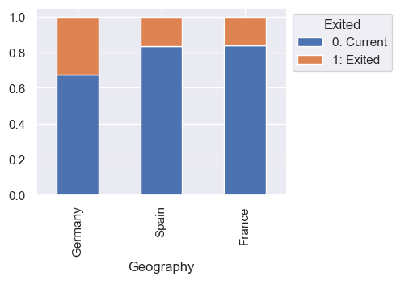

```python
stacked_barplot(df, 'Geography', 'Exited')
```

```
Exited     0     1    All  % of 0  % of 1
Gender
All     7963  2037  10000  79.630  20.370
Female  3404  1139   4543  74.930  25.070
Male    4559   898   5457  83.540  16.460
------------------------------------------------------------------------------------------------------------------------
```

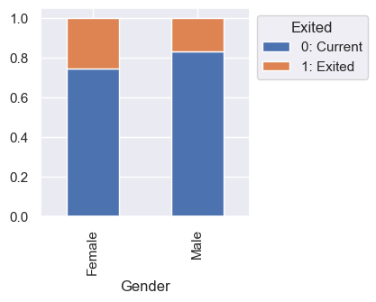

```python
stacked_barplot(df, 'Gender', 'Exited')
```

```
Exited            0     1    All  % of 0  % of 1
NumOfProducts
All            7963  2037  10000  79.630  20.370
1              3675  1409   5084  72.290  27.710
2              4242   348   4590  92.420   7.580
3                46   220    266  17.290  82.710
4                 0    60     60   0.000 100.000
------------------------------------------------------------------------------------------------------------------------
```

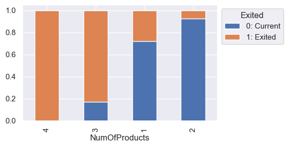

```python
stacked_barplot(df, 'NumOfProducts', 'Exited')
```

##### Observations:

- Customers in Germany have a 16% higher or double the attrition rate than in France and Spain.
- Females are 9% more likely to churn than males.
- All customers with 4 number of products had churn 100%.

## Data Preprocessing

```python
df1 = df.copy()
```

```python
# Separating Independent and Dependent Columns
X = df1.drop(['Exited'], axis=1)
y = df1['Exited']
```

```python
# Numerical columns
num_cols = X.select_dtypes(include=np.number).columns.tolist()
num_cols
```

```
['CreditScore',
 'Age',
 'Tenure',
 'Balance',
 'NumOfProducts',
 'HasCrCard',
 'IsActiveMember',
 'EstimatedSalary']
```

```python
# Categorical columns
cat_cols
```

```
['Geography', 'Gender']
```

```python
# Overview
X.head()
```

|  | CreditScore | Geography | Gender | Age | Tenure | Balance | NumOfProducts | HasCrCard | IsActiveMember | EstimatedSalary |
| --- | --- | --- | --- | --- | --- | --- | --- | --- | --- | --- |
| 0 | 619 | France | Female | 42 | 2 | 0.000 | 1 | 1 | 1 | 101348.880 |
| 1 | 608 | Spain | Female | 41 | 1 | 83807.860 | 1 | 0 | 1 | 112542.580 |
| 2 | 502 | France | Female | 42 | 8 | 159660.800 | 3 | 1 | 0 | 113931.570 |
| 3 | 699 | France | Female | 39 | 1 | 0.000 | 2 | 0 | 0 | 93826.630 |
| 4 | 850 | Spain | Female | 43 | 2 | 125510.820 | 1 | 1 | 1 | 79084.100 |

### Train-validation-test Split

```python
# Splitting the dataset into the Training, Validation, and Test set.
X_train, X_test, y_train, y_test = train_test_split(X, y, test_size=0.2, random_state=42, stratify=y)
X_train, X_val, y_train, y_val = train_test_split(X_train, y_train, test_size=0.2, random_state=42, stratify=y_train)
```

```python
# Overview
print(X_train.shape, y_train.shape)
print(X_val.shape, y_val.shape)
print(X_test.shape, y_test.shape)
```

```
(6400, 10) (6400,)
(1600, 10) (1600,)
(2000, 10) (2000,)
```

```python
'''
# Codes to preprocess data manually
encoder = OneHotEncoder(handle_unknown='ignore', sparse_output=False).set_output(transform='pandas')
ohe = encoder.fit_transform(X[cat_cols])
X = pd.concat([X, ohe], axis=1).drop(columns = cat_cols)

# Standardizing the numerical variables to zero mean and unit variance
scaler = StandardScaler()
X[num_cols] = scaler.fit_transform(X[num_cols])
'''
```

```
"\n# Codes to preprocess data manually\nencoder = OneHotEncoder(handle_unknown='ignore', sparse_output=False).set_output(transform='pandas')\nohe = encoder.fit_transform(X[cat_cols])\nX = pd.concat([X, ohe], axis=1).drop(columns = cat_cols)\n\n# Standardizing the numerical variables to zero mean and…
```

#### Pipeline with OneHotEncoder and StandardScaler

```python
# Define sklearn transformers to apply StandardScaler, and ONeHotEncoding.

numerical_transformer = Pipeline(steps = [('scaler', StandardScaler())])

categorical_transformer = Pipeline(steps=[('onehot', OneHotEncoder(handle_unknown='ignore', sparse_output=False)),])

preprocessor = ColumnTransformer(transformers = [
        ('num', numerical_transformer, num_cols),
        ('cat', categorical_transformer, cat_cols),
    ],
    remainder='passthrough',
    n_jobs = -1
)
```

```python
# These sample datasets are resampled for demonstration purposes only.
X_sample = preprocessor.fit_transform(X_train)
```

```python
X_sample.head()
```

|  | num__CreditScore | num__Age | num__Tenure | num__Balance | num__NumOfProducts | num__HasCrCard | num__IsActiveMember | num__EstimatedSalary | cat__Geography_France | cat__Geography_Germany | cat__Geography_Spain | cat__Gender_Female | cat__Gender_Male |
| --- | --- | --- | --- | --- | --- | --- | --- | --- | --- | --- | --- | --- | --- |
| 3006 | 0.989 | 0.573 | -1.385 | 0.611 | -0.910 | 0.639 | -1.035 | 1.566 | 1.000 | 0.000 | 0.000 | 1.000 | 0.000 |
| 5735 | -0.684 | 0.478 | -0.355 | -1.237 | 0.804 | -1.565 | 0.966 | 0.036 | 0.000 | 0.000 | 1.000 | 1.000 | 0.000 |
| 5652 | 0.410 | -0.948 | 1.361 | -1.237 | 0.804 | -1.565 | -1.035 | 1.745 | 1.000 | 0.000 | 0.000 | 1.000 | 0.000 |
| 26 | 1.082 | -0.283 | -1.042 | 0.962 | -0.910 | 0.639 | 0.966 | 1.229 | 0.000 | 1.000 | 0.000 | 0.000 | 1.000 |
| 3596 | -0.085 | -0.283 | -1.728 | 1.144 | -0.910 | -1.565 | -1.035 | -0.765 | 1.000 | 0.000 | 0.000 | 0.000 | 1.000 |

## Model Building

### Utility functions

```python
# Plotting the loss and accuracy curves
def plot(history, name):
    '''
    Function to plot loss/accuracy

    history: an object which stores the metrics and losses.
    name: can be one of Loss or Accuracy
    '''
    fig, ax = plt.subplots() #Creating a subplot with figure and axes.
    plt.plot(history.history_[name]) #Plotting the train accuracy or train loss
    plt.plot(history.history_['val_'+name]) #Plotting the validation accuracy or validation loss

    plt.title('Model ' + name.capitalize()) #Defining the title of the plot.
    plt.ylabel(name.capitalize()) #Capitalizing the first letter.
    plt.xlabel('Epoch') #Defining the label for the x-axis.
    fig.legend(['Train', 'Validation'], loc='outside right upper') #Defining the legend, loc controls the position of the legend.
```

```python
# defining a function to compute different metrics to check performance of a classification model built using sklearn
def model_performance_classification_sklearn(model, predictors, target):
    '''
    Function to compute different metrics to check classification model performance

    model: classifier
    predictors: independent variables
    target: dependent variable
    '''

    # predicting using the independent variables
    pred = model.predict(predictors)

    acc = accuracy_score(target, pred)  # to compute Accuracy
    recall = recall_score(target, pred)  # to compute Recall
    precision = precision_score(target, pred)  # to compute Precision
    f1 = f1_score(target, pred)  # to compute F1-score

    # creating a dataframe of metrics
    df_perf = pd.DataFrame(
        {
            'Accuracy': acc,
            'Recall': recall,
            'Precision': precision,
            'F1': f1

        },
        index=[0],
    )

    return df_perf
```

```python
# Function to plot confustion matrix with percentage
def confusion_matrix_sklearn(model, predictors, target):
    '''
    To plot the confusion_matrix with percentages

    model: classifier
    predictors: independent variables
    target: dependent variable
    '''
    y_pred = model.predict(predictors)
    cm = confusion_matrix(target, y_pred)
    labels = np.asarray(
        [
            ['{0:0.0f}'.format(item) + '\n{0:.2%}'.format(item / cm.flatten().sum())]
            for item in cm.flatten()
        ]
    ).reshape(2, 2)

    plt.figure(figsize=(6, 4))
    sns.heatmap(cm, annot=labels, fmt='')
    plt.ylabel('True label')
    plt.xlabel('Predicted label')
```

```python
# clears the current Keras session & seed
def reset_all():
    tf.keras.backend.clear_session()
    np.random.seed(42)
    random.seed(42)
    tf.keras.utils.set_random_seed(42)
```

### Model Evaluation Criterion

Write down the logic for choosing the metric that would be the best metric for this business scenario.

- The metric is Accuracy by default. [The weighted recall is equal to accuracy.](https://scikit-learn.org/stable/modules/generated/sklearn.metrics.recall_score.html)
- Recall metric is available.
- Bank churn is similar to credit card churn. So, we will evaluate the recall score afterward.

```python
# Calculate class weights for imbalanced dataset
cw = (y_train.shape[0]) / np.bincount(y_train)

# Create a dictionary mapping class indices to their respective class weights
cw_dict = {}
for i in range(cw.shape[0]):
    cw_dict[i] = cw[i]

cw_dict
```

```
{0: 1.2558869701726845, 1: 4.9079754601226995}
```

```python
# Initialization
epochs = 100
batch_size = 32
first_layer=32
second_layer=16
first_activation='relu'
second_activation='relu'
dropout_rate=0.1
kernel_initializer='he_normal'
input_dim = X_sample.shape[1]
learn_rate = 1e-3
```

#### Model architecture

```python
# function to return Keras model
def create_model(first_layer, first_activation, second_layer, second_activation,
              dropout_rate, optimizer, kernel_initializer, dropout_bool=True):
    model = Sequential()

    model.add(Dense(first_layer, activation=first_activation, kernel_initializer=kernel_initializer, input_dim=input_dim))
    if dropout_bool: model.add(Dropout(dropout_rate))
    model.add(Dense(second_layer, activation=second_activation, kernel_initializer=kernel_initializer))
    if dropout_bool: model.add(Dropout(dropout_rate))

    model.add(Dense(1, activation='sigmoid'))

    model.compile(loss='binary_crossentropy', optimizer=optimizer, metrics=[keras.metrics.Recall()])

    return model

early_stopping = EarlyStopping(monitor='val_loss', patience=10, restore_best_weights=True)
```

```python
# function to return a KerasClassifier model from Scikeras wrapper enhancing Scikit_learn (Pipeline, Gridsearch, RandomSearch, etc.)
def get_model(optimizer, dropout_bool):
    model = KerasClassifier(model=create_model,
            model__dropout_bool=dropout_bool, model__dropout_rate=dropout_rate,
            model__first_layer=first_layer, model__first_activation=first_activation,
            model__second_layer=second_layer, model__second_activation=second_activation,
            kernel_initializer=kernel_initializer, model__optimizer=optimizer, optimizer__learning_rate =learn_rate,
            batch_size=batch_size, epochs=epochs, class_weight=cw_dict,
            verbose=0, random_state=42, callbacks=[early_stopping] )
    return model
# validation_split = 0.2,
```

### Neural Network with SGD Optimizer

```python
reset_all()
```

```
WARNING:tensorflow:From C:\Users\Mark Le\AppData\Roaming\Python\Python311\site-packages\keras\src\backend\common\global_state.py:82: The name tf.reset_default_graph is deprecated. Please use tf.compat.v1.reset_default_graph instead.
```

```python
clf = get_model('SGD', False)
```

```python
pipeline = Pipeline(steps=[ ('preprocess', preprocessor),
                                ('clf', clf) ])
```

```python
start = time.time()
history = pipeline.fit(X_train, y_train, clf__validation_data = (preprocessor.transform(X_val),y_val))
end = time.time()
print('Time taken in seconds ', end-start)
```

```
Time taken in seconds  14.546552181243896
```

```python
clf.model_.summary()
```

```
Model: "sequential"
```

```
┏━━━━━━━━━━━━━━━━━━━━━━━━━━━━━━━━━┳━━━━━━━━━━━━━━━━━━━━━━━━┳━━━━━━━━━━━━━━━┓
┃ Layer (type)                    ┃ Output Shape           ┃       Param # ┃
┡━━━━━━━━━━━━━━━━━━━━━━━━━━━━━━━━━╇━━━━━━━━━━━━━━━━━━━━━━━━╇━━━━━━━━━━━━━━━┩
│ dense (Dense)                   │ (None, 32)             │           448 │
├─────────────────────────────────┼────────────────────────┼───────────────┤
│ dense_1 (Dense)                 │ (None, 16)             │           528 │
├─────────────────────────────────┼────────────────────────┼───────────────┤
│ dense_2 (Dense)                 │ (None, 1)              │            17 │
└─────────────────────────────────┴────────────────────────┴───────────────┘
```

```
 Total params: 995 (3.89 KB)
```

```
 Trainable params: 993 (3.88 KB)
```

```
 Non-trainable params: 0 (0.00 B)
```

```
 Optimizer params: 2 (12.00 B)
```

```python
model_0_train_perf = model_performance_classification_sklearn(history, X_train, y_train)
model_0_train_perf
```

|  | Accuracy | Recall | Precision | F1 |
| --- | --- | --- | --- | --- |
| 0 | 0.817 | 0.793 | 0.534 | 0.638 |

```python
model_0_val_perf = model_performance_classification_sklearn(history, X_val, y_val)
model_0_val_perf
```

|  | Accuracy | Recall | Precision | F1 |
| --- | --- | --- | --- | --- |
| 0 | 0.791 | 0.718 | 0.492 | 0.584 |

```python
display(pd.DataFrame(clf.history_).T)
```

|  | 0 | 1 | 2 | 3 | 4 | 5 | 6 | 7 | 8 | 9 | 10 | 11 | 12 | 13 | 14 | 15 | 16 | 17 | 18 | 19 | 20 | 21 | 22 | 23 | 24 | 25 | 26 | 27 | 28 | … |
| --- | --- | --- | --- | --- | --- | --- | --- | --- | --- | --- | --- | --- | --- | --- | --- | --- | --- | --- | --- | --- | --- | --- | --- | --- | --- | --- | --- | --- | --- | --- |
| loss | 1.335 | 1.206 | 1.156 | 1.121 | 1.091 | 1.063 | 1.038 | 1.016 | 0.997 | 0.982 | 0.970 | 0.960 | 0.951 | 0.944 | 0.938 | 0.933 | 0.928 | 0.924 | 0.920 | 0.916 | 0.912 | 0.909 | 0.906 | 0.903 | 0.900 | 0.898 | 0.895 | 0.893 | 0.891 | … |
| recall | 0.619 | 0.663 | 0.653 | 0.670 | 0.686 | 0.701 | 0.715 | 0.728 | 0.735 | 0.737 | 0.744 | 0.750 | 0.749 | 0.754 | 0.759 | 0.761 | 0.762 | 0.764 | 0.768 | 0.771 | 0.773 | 0.776 | 0.775 | 0.777 | 0.777 | 0.776 | 0.779 | 0.781 | 0.781 | … |
| val_loss | 0.645 | 0.607 | 0.582 | 0.563 | 0.548 | 0.534 | 0.522 | 0.512 | 0.504 | 0.496 | 0.490 | 0.485 | 0.482 | 0.478 | 0.476 | 0.473 | 0.471 | 0.469 | 0.467 | 0.465 | 0.464 | 0.464 | 0.462 | 0.461 | 0.460 | 0.460 | 0.459 | 0.459 | 0.458 | … |
| val_recall | 0.635 | 0.638 | 0.635 | 0.644 | 0.669 | 0.699 | 0.696 | 0.699 | 0.727 | 0.733 | 0.745 | 0.748 | 0.755 | 0.748 | 0.752 | 0.755 | 0.758 | 0.758 | 0.764 | 0.758 | 0.758 | 0.758 | 0.758 | 0.758 | 0.752 | 0.748 | 0.742 | 0.742 | 0.739 | … |

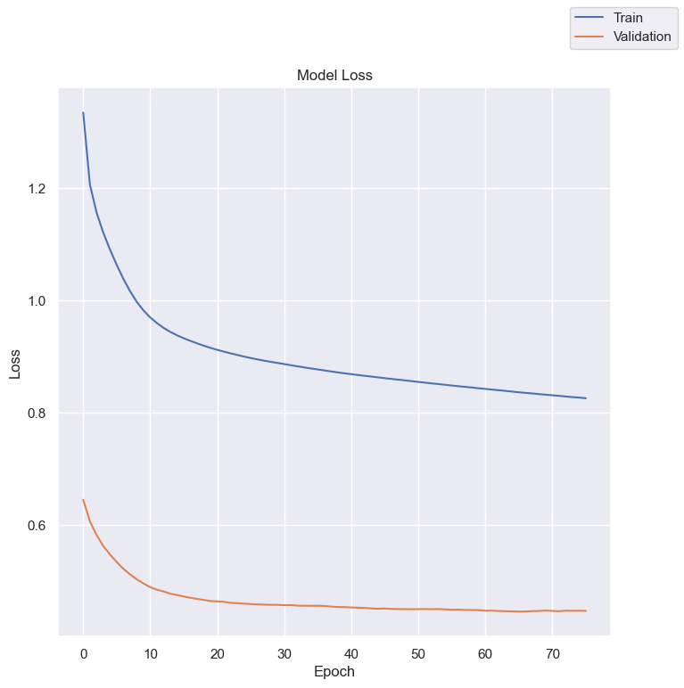

```python
plot(clf, 'loss')
```

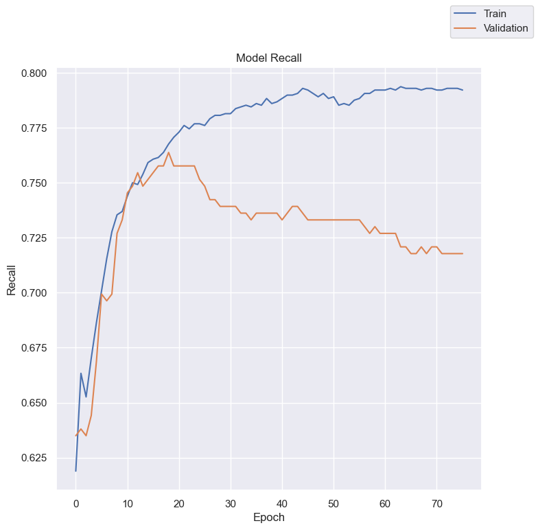

```python
plot(clf,'recall')
```

```python
y_train_pred = pipeline.predict(X_train)
y_train_pred = (y_train_pred > 0.5)
y_train_pred
```

```
array([ True, False, False, ..., False,  True, False])
```

```python
y_val_pred = pipeline.predict(X_val)
y_val_pred = (y_val_pred > 0.5)
y_val_pred
```

```
array([False, False, False, ..., False,  True,  True])
```

```python
print(classification_report(y_train, y_train_pred, digits=2))
```

```
              precision    recall  f1-score   support

           0       0.94      0.82      0.88      5096
           1       0.53      0.79      0.64      1304

    accuracy                           0.82      6400
   macro avg       0.74      0.81      0.76      6400
weighted avg       0.86      0.82      0.83      6400
```

```python
print(classification_report(y_val, y_val_pred, digits=2))
```

```
              precision    recall  f1-score   support

           0       0.92      0.81      0.86      1274
           1       0.49      0.72      0.58       326

    accuracy                           0.79      1600
   macro avg       0.70      0.76      0.72      1600
weighted avg       0.83      0.79      0.80      1600
```

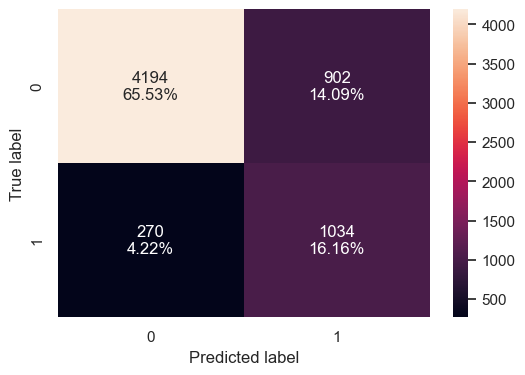

```python
confusion_matrix_sklearn(pipeline, X_train, y_train)
```

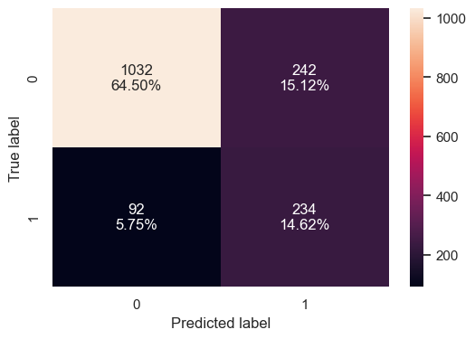

```python
confusion_matrix_sklearn(pipeline, X_val, y_val)
```

- The recall scores are good, with 0.793 for training data and 0.718 for validation data.
- The validation loss is below the training loss. It is underfitting. More epochs may be needed.
- From the history metrics, the entries of training and validation losses are going down continuously.

## Model Performance Improvement

### Neural Network with Adam Optimizer

```python
reset_all()
```

```python
clf = get_model('Adam', False)
```

```python
pipeline = Pipeline(steps=[ ('preprocess', preprocessor),
                                ('clf', clf) ])
```

```python
start = time.time()
history = pipeline.fit(X_train, y_train, clf__validation_data = (preprocessor.transform(X_val),y_val))
end = time.time()
print('Time taken in seconds ', end-start)
```

```
Time taken in seconds  3.173231363296509
```

```python
clf.model_.summary()
```

```
Model: "sequential"
```

```
┏━━━━━━━━━━━━━━━━━━━━━━━━━━━━━━━━━┳━━━━━━━━━━━━━━━━━━━━━━━━┳━━━━━━━━━━━━━━━┓
┃ Layer (type)                    ┃ Output Shape           ┃       Param # ┃
┡━━━━━━━━━━━━━━━━━━━━━━━━━━━━━━━━━╇━━━━━━━━━━━━━━━━━━━━━━━━╇━━━━━━━━━━━━━━━┩
│ dense (Dense)                   │ (None, 32)             │           448 │
├─────────────────────────────────┼────────────────────────┼───────────────┤
│ dense_1 (Dense)                 │ (None, 16)             │           528 │
├─────────────────────────────────┼────────────────────────┼───────────────┤
│ dense_2 (Dense)                 │ (None, 1)              │            17 │
└─────────────────────────────────┴────────────────────────┴───────────────┘
```

```
 Total params: 2,981 (11.65 KB)
```

```
 Trainable params: 993 (3.88 KB)
```

```
 Non-trainable params: 0 (0.00 B)
```

```
 Optimizer params: 1,988 (7.77 KB)
```

```python
model_1_train_perf = model_performance_classification_sklearn(history, X_train, y_train)
model_1_train_perf
```

|  | Accuracy | Recall | Precision | F1 |
| --- | --- | --- | --- | --- |
| 0 | 0.704 | 0.650 | 0.370 | 0.472 |

```python
model_1_val_perf = model_performance_classification_sklearn(history, X_val, y_val)
model_1_val_perf
```

|  | Accuracy | Recall | Precision | F1 |
| --- | --- | --- | --- | --- |
| 0 | 0.694 | 0.632 | 0.358 | 0.457 |

```python
display(pd.DataFrame(clf.history_).T)
```

|  | 0 | 1 | 2 | 3 | 4 | 5 | 6 | 7 | 8 | 9 |
| --- | --- | --- | --- | --- | --- | --- | --- | --- | --- | --- |
| loss | 1.309 | 1.138 | 1.069 | 1.016 | 0.979 | 0.954 | 0.938 | 0.925 | 0.916 | 0.909 |
| recall | 0.591 | 0.668 | 0.702 | 0.732 | 0.745 | 0.751 | 0.760 | 0.768 | 0.769 | 0.773 |
| val_loss | 0.592 | 0.546 | 0.518 | 0.497 | 0.483 | 0.473 | 0.466 | 0.460 | 0.456 | 0.453 |
| val_recall | 0.632 | 0.653 | 0.693 | 0.709 | 0.718 | 0.718 | 0.721 | 0.721 | 0.721 | 0.724 |

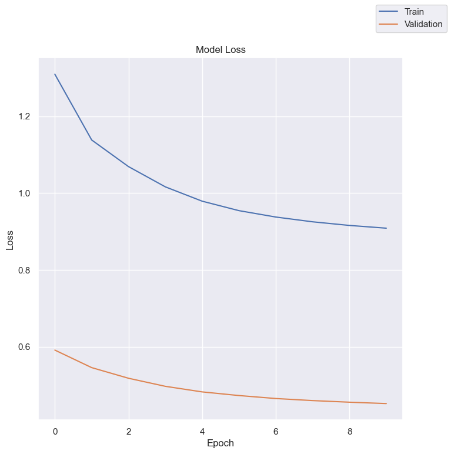

```python
plot(clf, 'loss')
```

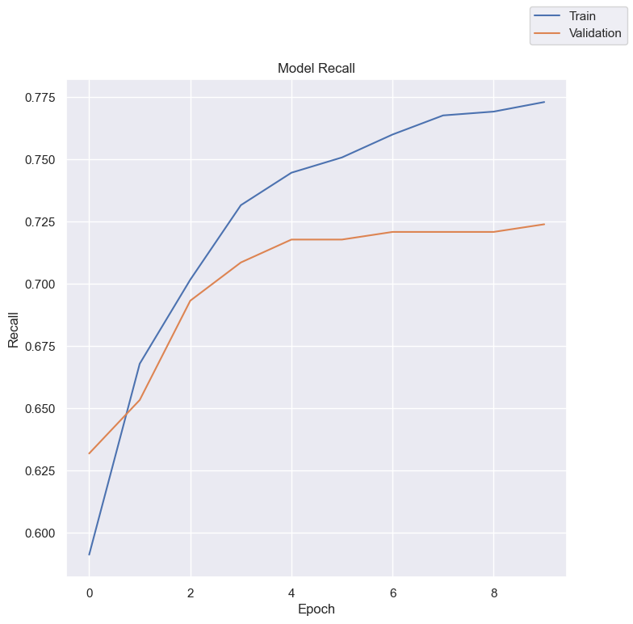

```python
plot(clf,'recall')
```

### Neural Network with Adam Optimizer and Dropout

```python
reset_all()
```

```python
clf = get_model('Adam', True)
```

```python
pipeline = Pipeline(steps=[ ('preprocess', preprocessor),
                                ('clf', clf) ])
```

```python
start = time.time()
history = pipeline.fit(X_train, y_train, clf__validation_data = (preprocessor.transform(X_val),y_val))
end = time.time()
print('Time taken in seconds ', end-start)
```

```
Time taken in seconds  3.3973379135131836
```

```python
clf.model_.summary()
```

```
Model: "sequential"
```

```
┏━━━━━━━━━━━━━━━━━━━━━━━━━━━━━━━━━┳━━━━━━━━━━━━━━━━━━━━━━━━┳━━━━━━━━━━━━━━━┓
┃ Layer (type)                    ┃ Output Shape           ┃       Param # ┃
┡━━━━━━━━━━━━━━━━━━━━━━━━━━━━━━━━━╇━━━━━━━━━━━━━━━━━━━━━━━━╇━━━━━━━━━━━━━━━┩
│ dense (Dense)                   │ (None, 32)             │           448 │
├─────────────────────────────────┼────────────────────────┼───────────────┤
│ dropout (Dropout)               │ (None, 32)             │             0 │
├─────────────────────────────────┼────────────────────────┼───────────────┤
│ dense_1 (Dense)                 │ (None, 16)             │           528 │
├─────────────────────────────────┼────────────────────────┼───────────────┤
│ dropout_1 (Dropout)             │ (None, 16)             │             0 │
├─────────────────────────────────┼────────────────────────┼───────────────┤
│ dense_2 (Dense)                 │ (None, 1)              │            17 │
└─────────────────────────────────┴────────────────────────┴───────────────┘
```

```
 Total params: 2,981 (11.65 KB)
```

```
 Trainable params: 993 (3.88 KB)
```

```
 Non-trainable params: 0 (0.00 B)
```

```
 Optimizer params: 1,988 (7.77 KB)
```

```python
model_2_train_perf = model_performance_classification_sklearn(history, X_train, y_train)
model_2_train_perf
```

|  | Accuracy | Recall | Precision | F1 |
| --- | --- | --- | --- | --- |
| 0 | 0.682 | 0.709 | 0.358 | 0.476 |

```python
model_2_val_perf = model_performance_classification_sklearn(history, X_val, y_val)
model_2_val_perf
```

|  | Accuracy | Recall | Precision | F1 |
| --- | --- | --- | --- | --- |
| 0 | 0.666 | 0.672 | 0.339 | 0.451 |

```python
display(pd.DataFrame(clf.history_).T)
```

|  | 0 | 1 | 2 | 3 | 4 | 5 | 6 | 7 | 8 | 9 |
| --- | --- | --- | --- | --- | --- | --- | --- | --- | --- | --- |
| loss | 1.447 | 1.207 | 1.134 | 1.108 | 1.060 | 1.045 | 1.012 | 1.005 | 0.992 | 0.995 |
| recall | 0.604 | 0.666 | 0.709 | 0.715 | 0.725 | 0.717 | 0.744 | 0.732 | 0.734 | 0.738 |
| val_loss | 0.612 | 0.580 | 0.551 | 0.530 | 0.510 | 0.499 | 0.483 | 0.478 | 0.480 | 0.473 |
| val_recall | 0.672 | 0.702 | 0.721 | 0.736 | 0.748 | 0.770 | 0.745 | 0.758 | 0.779 | 0.767 |

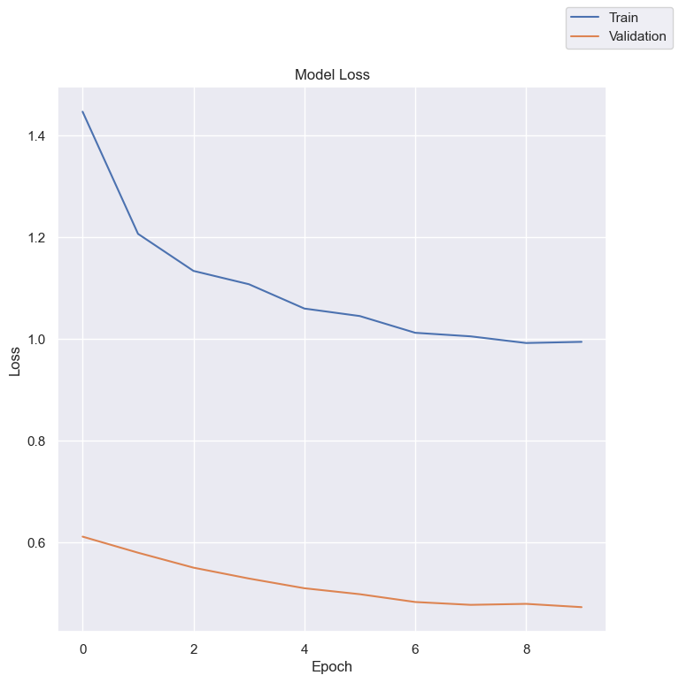

```python
plot(clf, 'loss')
```

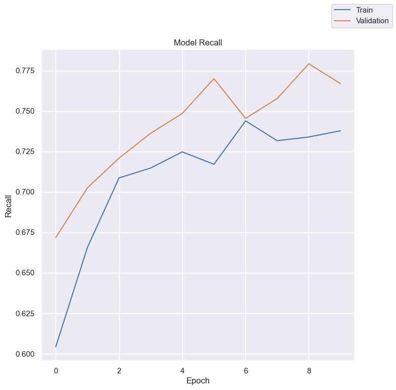

```python
plot(clf,'recall')
```

- The recall scores are low, with 0.709 for train data and 0.672 for validation data
- This model shows no improvement because the validation loss is still below the training loss.

#### Synthetic Minority Over Sampling Technique (SMOTE)

Note: This sample dataset is resampled for demonstration purposes only and is not used in the models.  
The pipeline will process this instead.

```python
print('Before Oversampling, counts of label "Yes": {}'.format(sum(y_train == 1)))
print('Before Oversampling, counts of label "No": {} \n'.format(sum(y_train == 0)))

# Synthetic Minority Over Sampling Technique
sm = SMOTE(
    sampling_strategy=1, k_neighbors=5, random_state=42
)

# Resample the dataset for display only
sm_pipe = imbPipeline(steps=[ ('preprocess', preprocessor),
                                ('smote', sm) ])
X_train_over, y_train_over = sm_pipe.fit_resample(X_train, y_train)


print('After Oversampling, counts of label "Yes": {}'.format(sum(y_train_over == 1)))
print('After Oversampling, counts of label "No": {} \n'.format(sum(y_train_over == 0)))

print('After Oversampling, the shape of X_train: {}'.format(X_train_over.shape))
print('After Oversampling, the shape of y_train: {} \n'.format(y_train_over.shape))

print('Data overview')
X_train_over.head()
```

```
Before Oversampling, counts of label "Yes": 1304
Before Oversampling, counts of label "No": 5096

After Oversampling, counts of label "Yes": 5096
After Oversampling, counts of label "No": 5096

After Oversampling, the shape of X_train: (10192, 13)
After Oversampling, the shape of y_train: (10192,)

Data overview
```

|  | num__CreditScore | num__Age | num__Tenure | num__Balance | num__NumOfProducts | num__HasCrCard | num__IsActiveMember | num__EstimatedSalary | cat__Geography_France | cat__Geography_Germany | cat__Geography_Spain | cat__Gender_Female | cat__Gender_Male |
| --- | --- | --- | --- | --- | --- | --- | --- | --- | --- | --- | --- | --- | --- |
| 0 | 0.989 | 0.573 | -1.385 | 0.611 | -0.910 | 0.639 | -1.035 | 1.566 | 1.000 | 0.000 | 0.000 | 1.000 | 0.000 |
| 1 | -0.684 | 0.478 | -0.355 | -1.237 | 0.804 | -1.565 | 0.966 | 0.036 | 0.000 | 0.000 | 1.000 | 1.000 | 0.000 |
| 2 | 0.410 | -0.948 | 1.361 | -1.237 | 0.804 | -1.565 | -1.035 | 1.745 | 1.000 | 0.000 | 0.000 | 1.000 | 0.000 |
| 3 | 1.082 | -0.283 | -1.042 | 0.962 | -0.910 | 0.639 | 0.966 | 1.229 | 0.000 | 1.000 | 0.000 | 0.000 | 1.000 |
| 4 | -0.085 | -0.283 | -1.728 | 1.144 | -0.910 | -1.565 | -1.035 | -0.765 | 1.000 | 0.000 | 0.000 | 0.000 | 1.000 |

### Neural Network with Balanced Data (by applying SMOTE) and SGD Optimizer

```python
reset_all()
```

```python
clf = get_model('SGD', False)
```

```python
sm_pipe = imbPipeline(steps=[ ('preprocess', preprocessor),
                                ('smote', sm),
                                ('clf', clf)])
```

```python
start = time.time()
history = sm_pipe.fit(X_train, y_train, clf__validation_data = (preprocessor.transform(X_val),y_val))
end = time.time()
print('Time taken in seconds ', end-start)
```

```
Time taken in seconds  3.2033021450042725
```

```python
clf.model_.summary()
```

```
Model: "sequential"
```

```
┏━━━━━━━━━━━━━━━━━━━━━━━━━━━━━━━━━┳━━━━━━━━━━━━━━━━━━━━━━━━┳━━━━━━━━━━━━━━━┓
┃ Layer (type)                    ┃ Output Shape           ┃       Param # ┃
┡━━━━━━━━━━━━━━━━━━━━━━━━━━━━━━━━━╇━━━━━━━━━━━━━━━━━━━━━━━━╇━━━━━━━━━━━━━━━┩
│ dense (Dense)                   │ (None, 32)             │           448 │
├─────────────────────────────────┼────────────────────────┼───────────────┤
│ dense_1 (Dense)                 │ (None, 16)             │           528 │
├─────────────────────────────────┼────────────────────────┼───────────────┤
│ dense_2 (Dense)                 │ (None, 1)              │            17 │
└─────────────────────────────────┴────────────────────────┴───────────────┘
```

```
 Total params: 995 (3.89 KB)
```

```
 Trainable params: 993 (3.88 KB)
```

```
 Non-trainable params: 0 (0.00 B)
```

```
 Optimizer params: 2 (12.00 B)
```

```python
model_3_train_perf = model_performance_classification_sklearn(history, X_train, y_train)
model_3_train_perf
```

|  | Accuracy | Recall | Precision | F1 |
| --- | --- | --- | --- | --- |
| 0 | 0.301 | 0.984 | 0.224 | 0.365 |

```python
model_3_val_perf = model_performance_classification_sklearn(history, X_val, y_val)
model_3_val_perf
```

|  | Accuracy | Recall | Precision | F1 |
| --- | --- | --- | --- | --- |
| 0 | 0.303 | 0.982 | 0.224 | 0.365 |

```python
display(pd.DataFrame(clf.history_).T)
```

|  | 0 | 1 | 2 | 3 | 4 | 5 | 6 | 7 | 8 | 9 |
| --- | --- | --- | --- | --- | --- | --- | --- | --- | --- | --- |
| loss | 1.438 | 1.295 | 1.240 | 1.192 | 1.151 | 1.118 | 1.094 | 1.076 | 1.063 | 1.052 |
| recall | 0.965 | 0.986 | 0.979 | 0.973 | 0.968 | 0.962 | 0.958 | 0.955 | 0.953 | 0.952 |
| val_loss | 1.069 | 1.001 | 0.952 | 0.910 | 0.873 | 0.843 | 0.819 | 0.801 | 0.788 | 0.776 |
| val_recall | 0.982 | 0.966 | 0.954 | 0.945 | 0.939 | 0.933 | 0.926 | 0.920 | 0.917 | 0.917 |

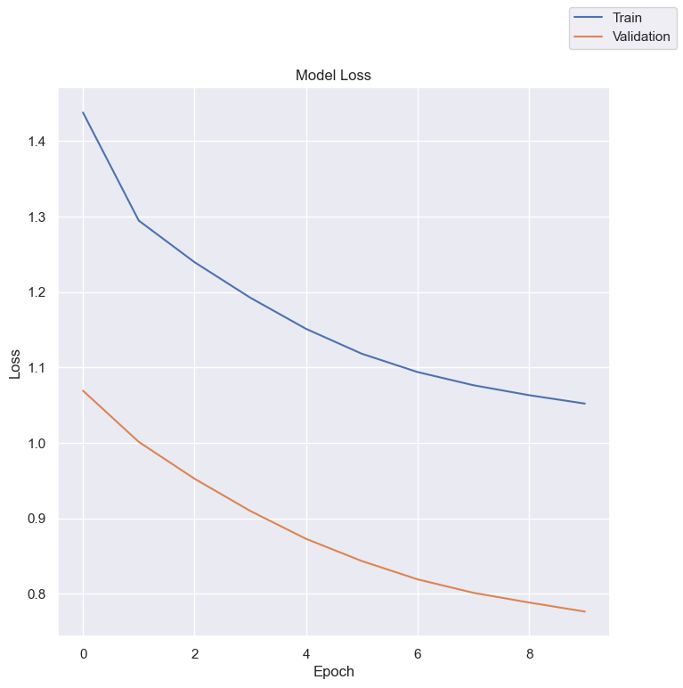

```python
plot(clf, 'loss')
```

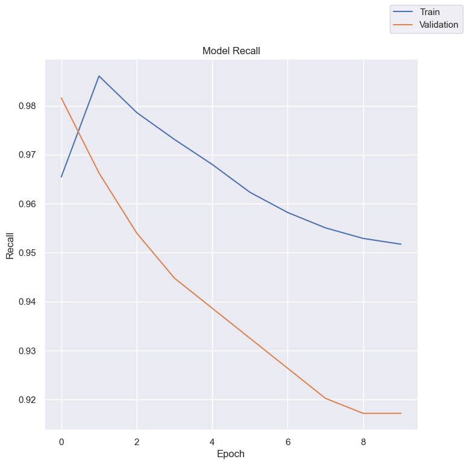

```python
plot(clf,'recall')
```

- The recall scores are 0.984 for train data and 0.982 for validation data, Early stopping is at 10 epochs.
- This model is doing much better. However, the loss curves are still not trying to converge.

### Neural Network with Balanced Data (by applying SMOTE) and Adam Optimizer

```python
reset_all()
```

```python
clf = get_model('Adam', False)
```

```python
sm_pipe = imbPipeline(steps=[ ('preprocess', preprocessor),
                                ('smote', sm),
                                ('clf', clf)])
```

```python
start = time.time()
history = sm_pipe.fit(X_train, y_train, clf__validation_data = (preprocessor.transform(X_val),y_val))
end = time.time()
print('Time taken in seconds ', end-start)
```

```
Time taken in seconds  4.148197889328003
```

```python
clf.model_.summary()
```

```
Model: "sequential"
```

```
┏━━━━━━━━━━━━━━━━━━━━━━━━━━━━━━━━━┳━━━━━━━━━━━━━━━━━━━━━━━━┳━━━━━━━━━━━━━━━┓
┃ Layer (type)                    ┃ Output Shape           ┃       Param # ┃
┡━━━━━━━━━━━━━━━━━━━━━━━━━━━━━━━━━╇━━━━━━━━━━━━━━━━━━━━━━━━╇━━━━━━━━━━━━━━━┩
│ dense (Dense)                   │ (None, 32)             │           448 │
├─────────────────────────────────┼────────────────────────┼───────────────┤
│ dense_1 (Dense)                 │ (None, 16)             │           528 │
├─────────────────────────────────┼────────────────────────┼───────────────┤
│ dense_2 (Dense)                 │ (None, 1)              │            17 │
└─────────────────────────────────┴────────────────────────┴───────────────┘
```

```
 Total params: 2,981 (11.65 KB)
```

```
 Trainable params: 993 (3.88 KB)
```

```
 Non-trainable params: 0 (0.00 B)
```

```
 Optimizer params: 1,988 (7.77 KB)
```

```python
model_4_train_perf = model_performance_classification_sklearn(history, X_train, y_train)
model_4_train_perf
```

|  | Accuracy | Recall | Precision | F1 |
| --- | --- | --- | --- | --- |
| 0 | 0.375 | 0.973 | 0.242 | 0.388 |

```python
model_4_val_perf = model_performance_classification_sklearn(history, X_val, y_val)
model_4_val_perf
```

|  | Accuracy | Recall | Precision | F1 |
| --- | --- | --- | --- | --- |
| 0 | 0.367 | 0.966 | 0.239 | 0.384 |

```python
display(pd.DataFrame(clf.history_).T)
```

|  | 0 | 1 | 2 | 3 | 4 | 5 | 6 | 7 | 8 | 9 |
| --- | --- | --- | --- | --- | --- | --- | --- | --- | --- | --- |
| loss | 1.484 | 1.217 | 1.131 | 1.072 | 1.039 | 1.017 | 1.000 | 0.986 | 0.973 | 0.962 |
| recall | 0.923 | 0.972 | 0.964 | 0.956 | 0.954 | 0.953 | 0.953 | 0.953 | 0.954 | 0.956 |
| val_loss | 1.030 | 0.938 | 0.870 | 0.832 | 0.811 | 0.796 | 0.782 | 0.773 | 0.770 | 0.763 |
| val_recall | 0.966 | 0.957 | 0.933 | 0.929 | 0.920 | 0.920 | 0.917 | 0.908 | 0.902 | 0.899 |

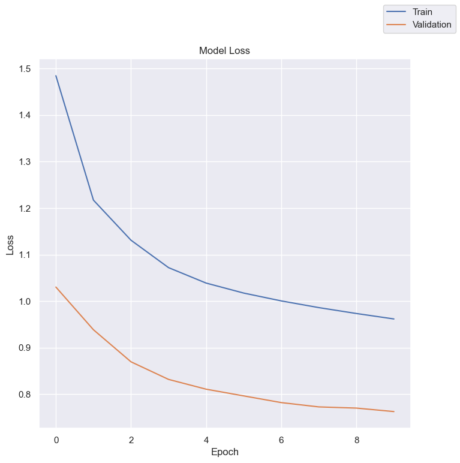

```python
plot(clf, 'loss')
```

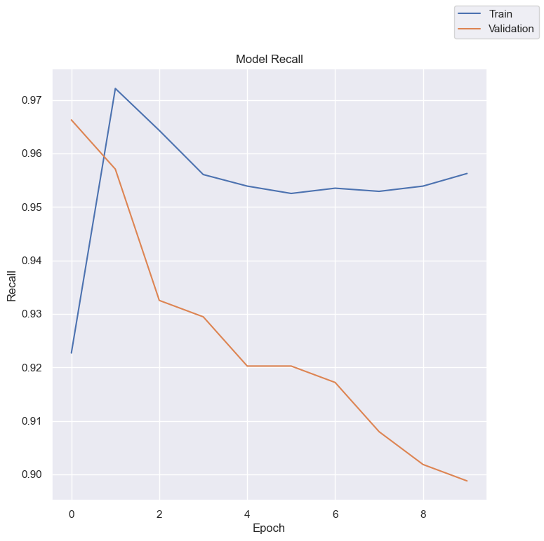

```python
plot(clf,'recall')
```

- The recall scores are very good, with 0.973 for train data and 0.966 for validation data
- The training data seems a bit harder to model than the validation data.
- The lost curves do not seem to come together. It is underfitting.